# Homework 3

## Geo-spatial Analysis and Visualization

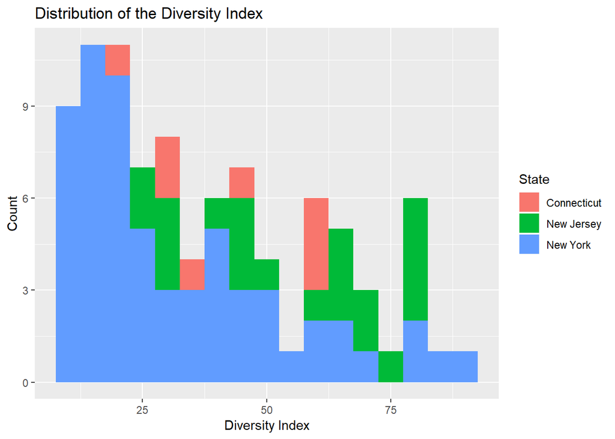

```r
library(ggplot2)
library(leaflet)

#6

ggplot(race_and_ethnicity, aes(x=DiversityIndex, fill = State)) + geom_histogram(binwidth = 5) + labs(x = "Diversity Index", y = "Count", title = "Distribution of the Diversity Index")
```

The histogram appears to be right-skewed. Thus, the mean is greater than the median.

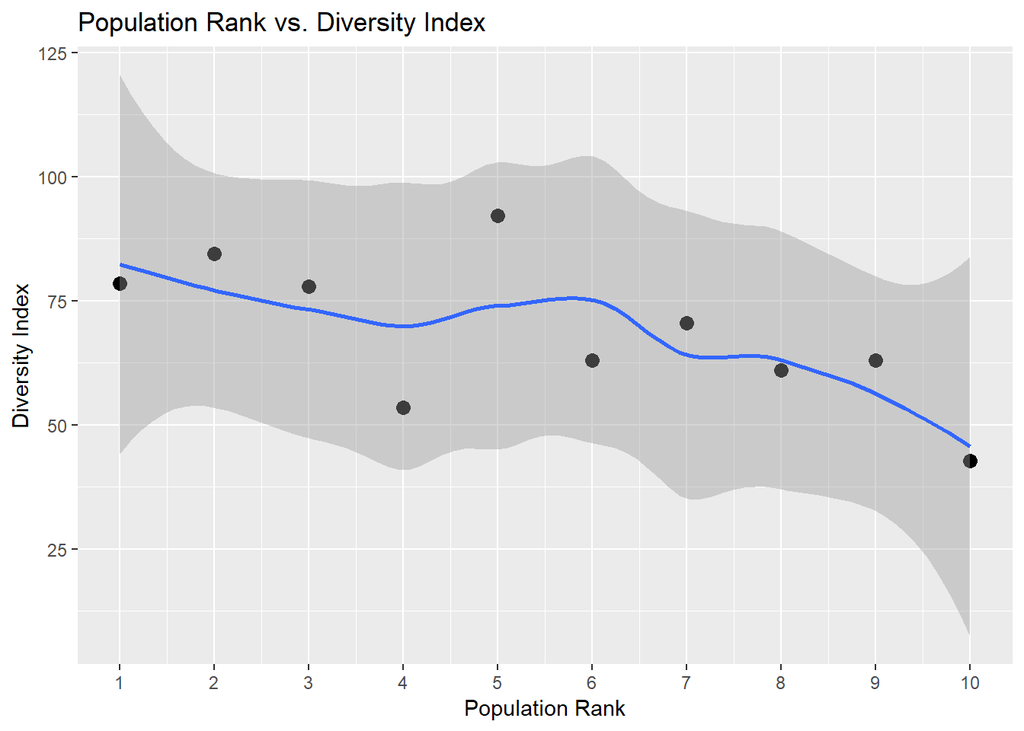

```r
#7

#Chart with top 10 counties by population
race_and_ethnicity <- race_and_ethnicity %>% arrange(desc(total_pop))

race_and_ethnicity[1:10,] %>% mutate(Population_Rank = 1:10) %>%
  ggplot(aes(x=Population_Rank, y = DiversityIndex)) +
  geom_point(size = 3) +
  geom_smooth() +
  scale_x_continuous(breaks = seq(1, 10, by = 1)) +
  labs(x = "Population Rank", y = "Diversity Index", title = "Population Rank vs. Diversity Index")
```

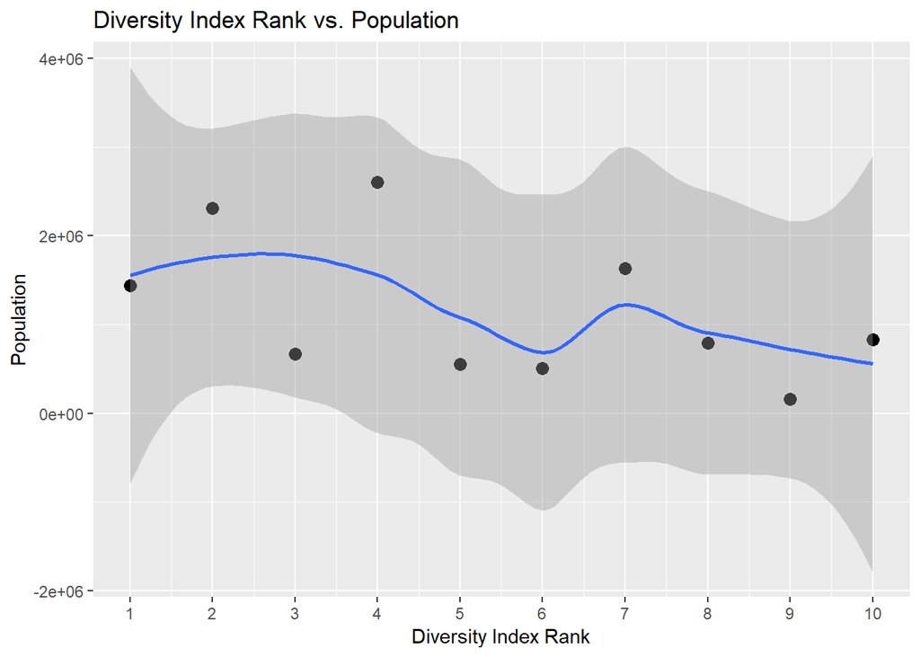

```r
#Chart with top 10 counties by Diversity Index
race_and_ethnicity <- race_and_ethnicity %>% arrange(desc(DiversityIndex))

race_and_ethnicity[1:10,] %>% mutate(Diversity_Rank = 1:10) %>%
  ggplot(aes(x=Diversity_Rank, y = total_pop)) +
  geom_point(size = 3) +
  geom_smooth() +
  scale_x_continuous(breaks = seq(1, 10, by = 1)) +
  labs(x = "Diversity Index Rank", y = "Population", title = "Diversity Index Rank vs. Population")
```

```r
#8 & #9

pal <- colorQuantile(palette = "viridis", domain = race_and_ethnicity$DiversityIndex, n = 10)

race_and_ethnicity %>%
  leaflet(width = "100%") %>%
  addProviderTiles(provider = "CartoDB.Positron") %>%
  addPolygons(label = ~ (paste0(County, " - ", "Diversity Index: ", format(round(DiversityIndex, 2), nsmall = 2))
),
              stroke = FALSE,
              smoothFactor = 0,
              fillOpacity = 0.7,
              color = ~ pal(DiversityIndex)) %>%
  addLegend("bottomright",
            pal = pal,
            values = ~ DiversityIndex,
            title = "DiversityIndex",
            opacity = 1)
```

[interactive chart not shown]

10. As can be seen in the plot, the most diverse areas tend to be concentrated in the New York City & Philadelphia areas. Upstate NY and the counties in Connecticut bordering Massachussets are the least diverse. On the other hand, Downstate NY, New Jersey, and the counties in Connecticut bordering New York all rank highly on the diversity index.

## Extra Credit

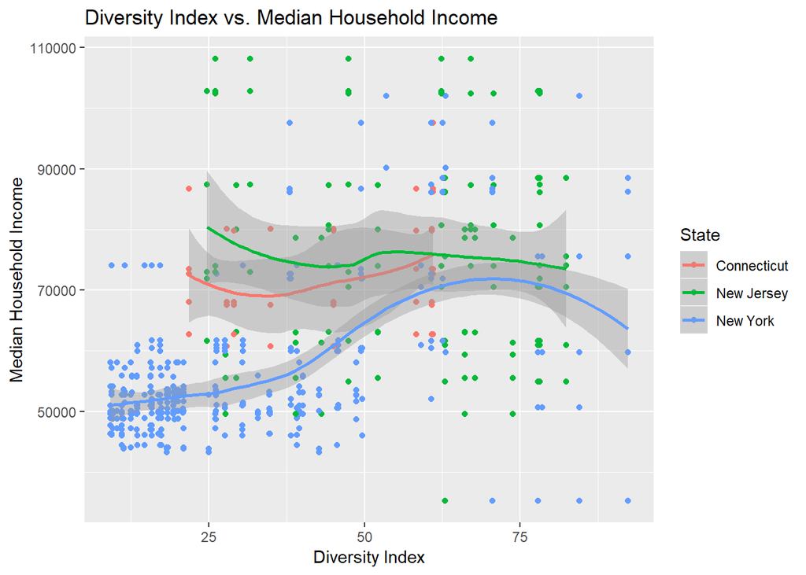

```r
#11

household_income <- get_acs(geography = "county", variables = c(medincome = "B19013_001"), state = c("NY", "NJ", "CT"), geometry = TRUE)

household_income <- household_income %>% select(-NAME, -GEOID, -variable)

combined_data <- st_join(race_and_ethnicity, household_income)

combined_data <- combined_data %>% rename(Median_Household_Income = estimate)

ggplot(combined_data, aes(x=DiversityIndex, y = Median_Household_Income)) +
  geom_point(mapping = aes(color = State)) +
  geom_smooth(mapping = aes(color = State)) +
  labs(x = "Diversity Index", y = "Median Household Income", title = "Diversity Index vs. Median Household Income")
```

12. There appears to be no relationship between the median household income and Diversity Index in Connecticut and New Jersey. However, in New York, there is a positive correlation between the median household income and Diversity Index. This likely occurs because the least diverse areas of New York are in upstate NY, which has a much lower cost of living than the NYC metropolitan area. Since the cost of living is much lower, we would expect to see lower income on average, which is exactly what we see in the plot above.